# Etude de données sur les élections présidentielles en Indre-Et-Loire

Nonga-Sara KIDINDA et Sandy PAYS

# Introduction

Les élections, qu’elles soient locales, nationales ou européennes, sont profondément influencées par de multiples facteurs. Parmi ces derniers, les caractéristiques géographiques et démographiques, ainsi que la diversité des listes de candidats, jouent un rôle déterminant dans les comportements électoraux. Comprendre ces dynamiques est essentiel pour analyser les choix des citoyens et les résultats des scrutins.  
Les élections présidentielles, moment central de la vie démocratique française, orientent les priorités politiques nationales pour plusieurs années. Chaque département ou commune devient alors un terrain d’analyse unique, révélant des disparités significatives dans les comportements électoraux.  
Nous allons prendre le cas du département de l’Indre-et-Loire qui nous offre un large champ d’étude quant à sa diversité géographique et démographique. De ce fait, nous allons nous demander :

**Comment les dynamiques géographiques et démographiques influencent-elles les résultats des élections présidentielles dans l’Indre-et-Loire ?**

# Présentation des données

Pour commencer, nous allons *travailler* sur les résultats généraux dans les bureaux de vote d’**Indre-et-Loire** lors des élections françaises.

La base de données des résultats généraux contient, par bureau de vote :

- le nombre d’inscrits ;
- de votants ;
- de votes blancs ;
- de votes nuls ;
- etc.

Dans notre étude, nous allons *travailler* sur les résultats des élections présidentielles en 2022 dans les bureaux de vote en Indre-et-Loire.

Les données de participation au premier tour des élections présidentielles en Indre-et-Loire en 2022 sont telles qu’il y a :

- **440502 inscrits** sur les listes électorales.
- **334966 votants** sur les listes électorales.
- **105536 abstentions** lors de ces élections présidentielles.

# Analyse des taux de participation

## Variations entre métropole et hors métropole

L’analyse des taux de participation en Indre-et-Loir, en distinguant la métropole et la zone hors métropole, permet de mieux comprendre les disparités dans l’engagement électoral au sein du département, en tenant compte des facteurs socio-économiques et géographiques qui influencent la mobilisation des électeurs.

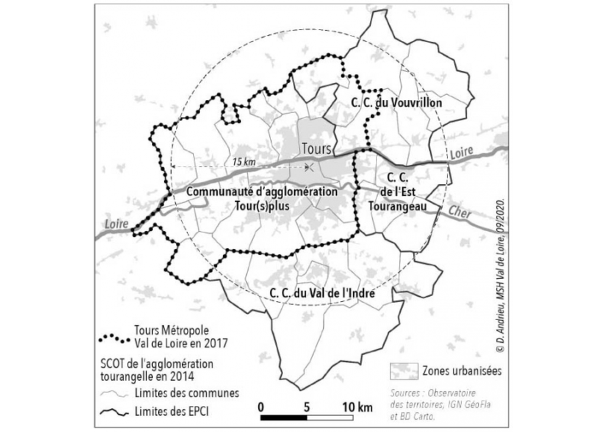

Pour cela, nous avons calculé le **taux de participation moyen et médian en métropole et hors métropole** afin d’analyser les variations d’engagement électoral entre ces deux zones, dans le but de mieux comprendre comment les contextes géographiques et socio-économiques influencent la mobilisation des électeurs dans ces différentes catégories de communes.

| Métropole | Participation moyenne (%) | Participation médiane (%) |
| --- | --- | --- |
| Hors métropole | 77.7 | 78.3 |
| Métropole | 74.1 | 75.9 |

On constate que *50% des villes hors métropole* ont un taux de participation **supérieur à 78.3%**, et l’autre moitié à un taux de participation inférieur à cette valeur.

D’autre part, la moitié des villes en métropole ont un taux de participation **supérieur à 75.9%**, tandis que l’autre moitié à un taux de participation inférieur à cette valeur.

Dans les deux cas, la médiane est un peu plus élevée que la moyenne, ce qui suggère que la distribution des taux de participation est légèrement biaisée vers les faibles taux de participation dans chaque groupe.

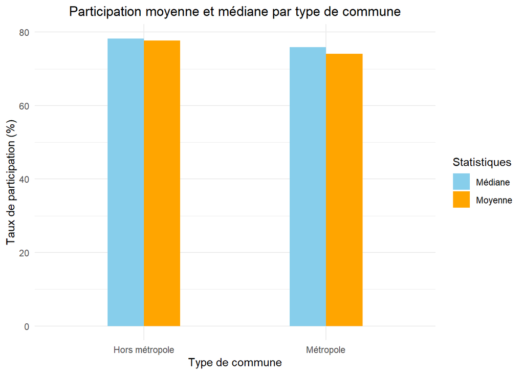

Ce graphique présente la comparaison des taux de participation électorale, en termes de participation moyenne globale et participation médiane, entre les communes de la métropole et celles hors de la métropole en Indre-et-Loir.

Par la suite, nous avons examiné la relation entre le **taux de participation** et le **niveau d’étude** des habitants de la **métropole**, dans le but de déterminer si un lien significatif existait entre l’éducation des électeurs et leur engagement politiquee en fonction de la zone géographique.  
De manière générale, les résultats sont les suivants :

| Niveau d’étude | Corrélation avec le taux de participation en métropole |
| --- | --- |
| Aucun diplôme | -0.803 |
| BEPC, brevet | 0.096 |
| CAP, BEP ou équivalent | 0.259 |
| Bac, brevet prof ou équivalent | -0.280 |
| Enseignement sup de niveau bac+2 | 0.737 |
| Enseignement sup de niveau bac+3+4 | 0.139 |
| Diplôme de niveau bac+5 ou plus | -0.007 |

On remarque que le taux de participation est plus élevé chez les personnes ayant un niveau d’éducation supérieur (notamment Bac+2). Cela peut refléter un plus grand intérêt pour la politique et une plus grande confiance dans le système démocratique parmi les personnes ayant un diplôme supérieur.

Tandis que le taux de participation est plus faible chez les personnes sans diplôme puisqu’il y a une forte corrélation négative entre ces 2 variables, ce qui peut indiquer une exclusion sociale ou un désintérêt pour la politique dans ce groupe.

Les personnes ayant des diplômes intermédiaires (comme BEPC, CAP, Bac) montrent des corrélations faibles, suggérant que ces groupes ne sont ni particulièrement plus ni moins enclins à participer par rapport aux autres groupes éducatifs.

En conclusion, il apparaît que **l’éducation joue un rôle clé dans la participation électorale**, en particulier le niveau d’enseignement supérieur tandis que les personnes ayant peu ou pas de diplôme semblent moins engagées dans le processus électoral. Cela pourrait être dû à des facteurs socio-économiques, culturels ou d’accès à l’information.

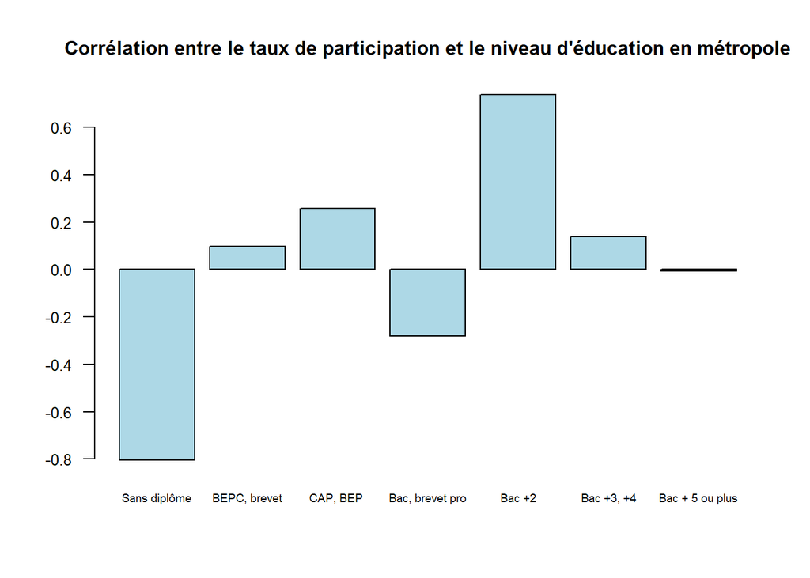

Nous avons également étudié la corrélation entre le **taux de participation** aux élections présidentielles de 2022 et le **niveau d’étude** des habitants en nous concentrant sur les données **hors métropole**.

| Niveau d’étude | Corrélation avec le taux de participation hors métropole |
| --- | --- |
| Aucun diplôme | -0.3763040 |
| BEPC, brevet | -0.0361430 |
| CAP, BEP ou équivalent | -0.1135387 |
| Bac, brevet prof ou équivalent | 0.0860957 |
| Enseignement sup de niveau bac+2 | 0.2335108 |
| Enseignement sup de niveau bac+3+4 | 0.2912775 |
| Diplôme de niveau bac+5 ou plus | 0.1807770 |

Ici, le taux de participation est plus faible parmi les personnes sans diplôme et les personnes ayant un niveau d’éducation inférieur comme le BEPC ou le CAP. Cela suggère que, bien que l’effet ne soit pas aussi fort que dans la métropole, les personnes ayant des niveaux d’éducation plus faibles sont généralement moins enclines à participer aux élections.

De même, le taux de participation est plus élevé chez les personnes ayant un niveau d’éducation supérieur (notamment Bac+2, Bac+3 et Bac+4). Cela suggère qu’un meilleur niveau d’éducation est associé à une participation plus active, bien que la corrélation ne soit pas aussi forte que dans la métropole.

Notons que les personnes ayant un Bac ou brevet professionnel ne montrent aucune relation claire avec la participation électorale, ce qui suggère une relative indifférence ou une absence de facteurs déterminants.

En dehors de la métropole, les résultats montrent une **corrélation positive modérée à faible entre l’éducation et la participation électorale**, particulièrement à partir du Bac+2. Les personnes ayant un faible niveau d’éducation (sans diplôme, BEPC, CAP) sont généralement moins susceptibles de participer aux élections, mais cette tendance est moins marquée qu’en métropole. L’effet de l’éducation sur la participation électorale semble donc présent, mais moins prononcé dans les zones rurales ou périphériques par rapport aux grandes agglomérations.

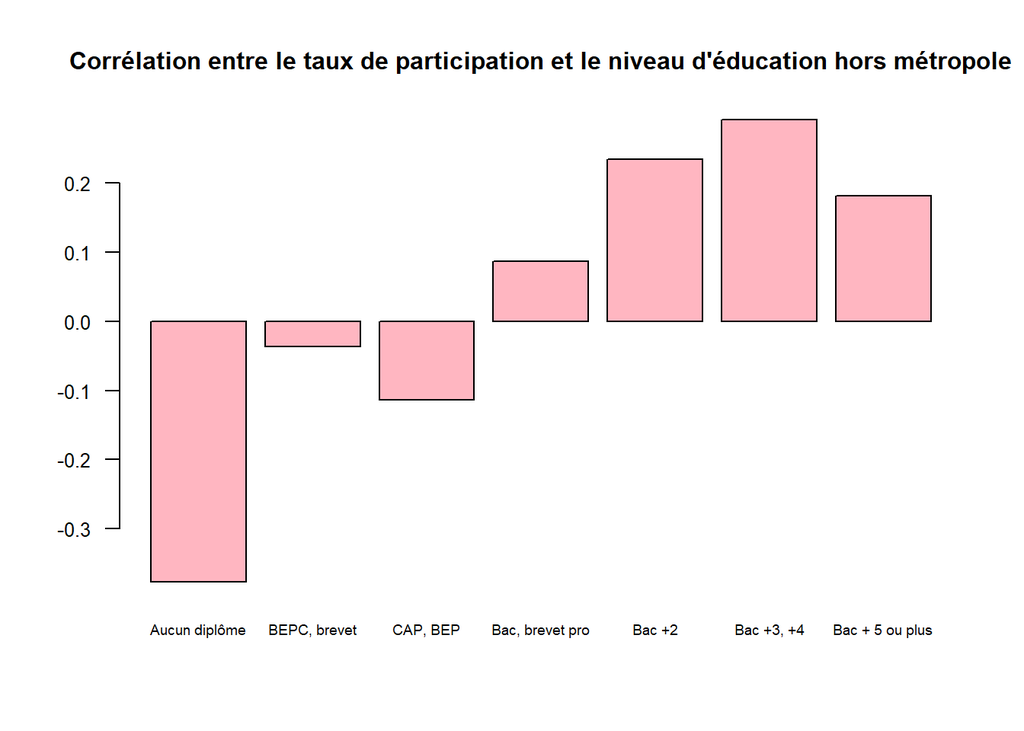

Par ailleurs, nous nous sommes également intéressés au lien entre la **participation électorale** et **l’âge** des habitants des différentes communes.

| Tranche d’âge | Corrélation avec le taux de participation en métropole |
| --- | --- |
| 15 à 24 ans | -0.623 |
| 25 à 54 ans | 0.064 |
| 55 à 64 ans | 0.450 |

| Tranche d’âge | Corrélation avec le taux de participation hors métropole |
| --- | --- |
| 15 à 24 ans | -0.1077308 |
| 25 à 54 ans | 0.2686742 |
| 55 à 64 ans | 0.0239395 |

Pour conclure, en métropole, la participation semble plus influencée par l’âge avec une forte corrélation négative chez les jeunes (15-24 ans) et une légère tendance positive chez les plus âgés (55-64 ans).  
Hors métropole, la participation est moins sensible à l’âge, avec une légère tendance positive pour les 25-54 ans, mais pratiquement aucune corrélation pour les autres tranches d’âge.

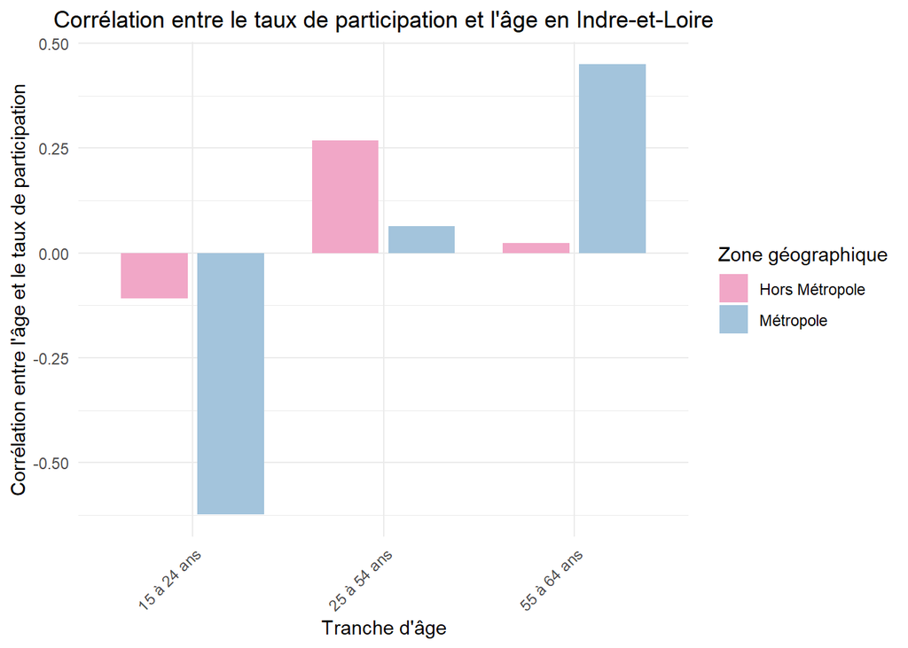

## Quelles communes présentent les taux de participation les plus élevés/les plus faibles ?

Nous allons analyser les taux de participation aux élections en fonction des différentes communes. L’objectif est d’identifier quelles communes ont enregistré les taux de participation les plus élevés et les plus faibles, afin de mieux comprendre les facteurs qui peuvent influencer la participation électorale au niveau local.

D’après la base de données, la ville avec le taux de participation minimum est **Château-Renault** avec un taux de **65 %** et la ville avec le taux de participation maximum est Esves-Le-Moutier avec un taux de **89 %**.

En analysant les taux de participation, on remarque que la ville de **Château-Renault**, qui présente le taux de participation le plus faible (65 %), se situe en zone **hors métropole**. De même, la ville de **Esves-Le-Moutier**, avec le taux de participation le plus élevé (89 %), appartient également à une zone **hors métropole**.  
Ces résultats soulignent que, malgré des disparités notables, les zones hors métropole semblent également avoir des taux de participation élevés, ce qui peut inviter à explorer davantage les facteurs spécifiques à ces territoires comme la taille des différentes communes.

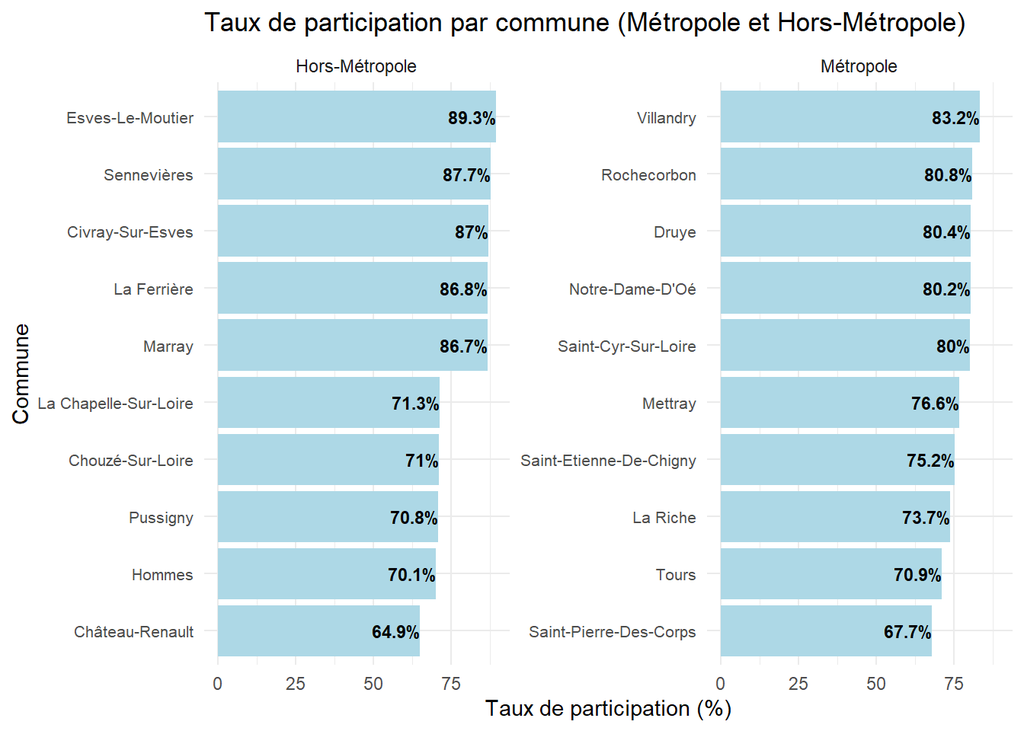

## Existe-t-il une relation entre la taille de la commune et la participation ?

Dans cette section, nous examinons la relation potentielle entre la *taille des communes*, mesurée par leur **superficie**, et le taux de **participation électorale**. L’objectif est de déterminer si les communes de plus grande taille, en termes de superficie, présentent des taux de participation plus élevés ou plus faibles, et d’évaluer si la taille géographique pourrait être un facteur influençant l’engagement électoral.

De ce fait, nous avons ajusté un modèle de régression linéaire pour examiner si une augmentation de la superficie des communes était associée à une variation du taux de participation.  
Pour cela, nous avons réalisé un test de corrélation grâce auquel nous avons obtenu une corrélation de **0.0895772** entre la **superficie des communes** et le **taux de participation**, ce qui indique une relation positive mais très faible. Cela signifie qu’une augmentation de la superficie des communes est légèrement associée à une augmentation du taux de participation électorale, bien que cette relation soit très faible et probablement non significative d’un point de vue pratique.

Cela suggère que la superficie seule n’explique pas de manière substantielle la variation du taux de participation électorale, et que d’autres facteurs peuvent avoir un impact beaucoup plus important comme nous l’avons vu précédemment avec le niveau d’éducation ou encore avec l’âge.

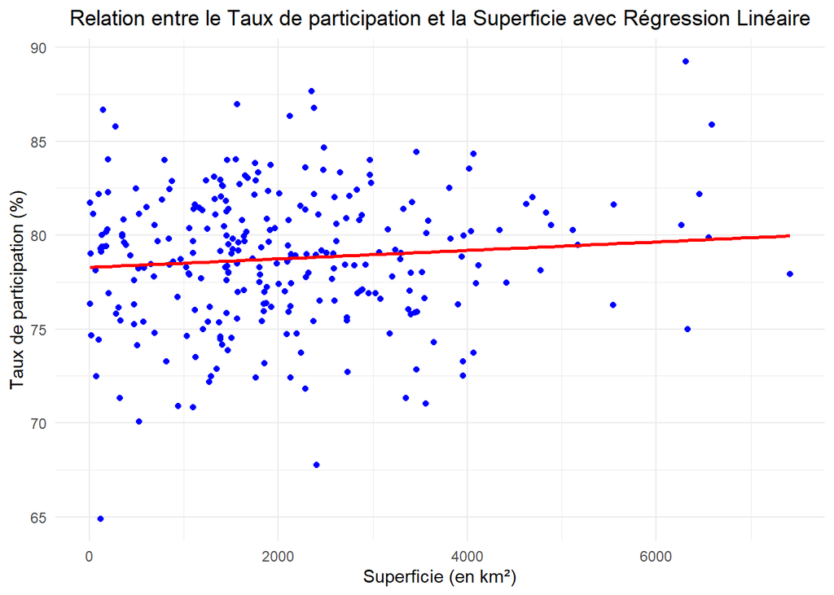

En conclusion, bien qu’il existe une relation positive entre la **superficie** des communes et leur **taux de participation**, cette relation est trop faible pour être considérée comme significative d’un point de vue statistique. Cela suggère que d’autres facteurs, tels que la **densité de population** ou des éléments **socio-économiques**, pourraient être plus influents dans l’explication du taux de participation électorale.

# L’influence des dynamiques démographiques sur les résultats électoraux

Les *dynamiques démographiques* ont un impact majeur sur les résultats électoraux, façonnant les comportements de vote et influençant les résultats dans les différentes zones géographiques. Avant d’explorer en détail ces interactions, nous commencerons par analyser les scores obtenus par les principaux candidats dans les élections récentes.  
Cette première analyse nous permettra de mieux comprendre les tendances générales et d’identifier d’éventuelles corrélations avec les caractéristiques démographiques des territoires. En étudiant les résultats des candidats, nous poserons les bases nécessaires pour examiner comment les facteurs comme la répartition géographique influencent les comportements électoraux et contribuent aux écarts de participation et de soutien politique.

Lors de cette élection, 12 candidats se sont présentés. Les candidats en lice étaient :  
- **Nathalie ARTHAUD**,  
- **Nicolas DUPONT-AIGNAN**,  
- **Anne HIDALGO**,  
- **Yannick JADOT**,  
- **Jean LASSALLE**,  
- **Marine LE PEN**,  
- **Emmanuel MACRON**,  
- **Jean-Luc MÉLENCHON**,  
- **Philippe POUTOU**,  
- **Valérie PÉCRESSE**,  
- **Fabien ROUSSEL** et  
- **Eric ZEMMOUR**

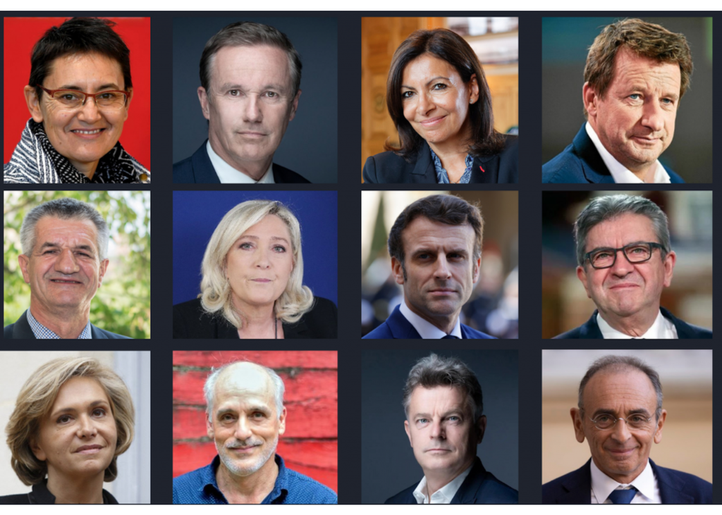

## Analyse des scores des principaux candidats

Parmi les 12 candidats mentionnés, les principaux candidats lors de l’élection présidentielle française de 2022 étaient les suivants :

- **Emmanuel MACRON** (Président sortant, candidat à sa réélection)
- **Marine LE PEN** (Rassemblement National)
- **Jean-Luc MÉLENCHON** (La France Insoumise)
- **Valérie PÉCRESSE** (Les Républicains)
- **Éric ZEMMOUR** (Reconquête!)

C’est pourquoi, nous allons nous intéresser à leurs scores au sein du département de l’Indre-et-Loire.

Résultats des principaux candidats à l’élection présidentielle de 2022 (Indre-et-Loire)

| Candidat | Voix |
| --- | --- |
| Emmanuel MACRON | 101503 |
| Marine LE PEN | 70553 |
| Jean-Luc MÉLENCHON | 68012 |
| Valérie PÉCRESSE | 16279 |
| Éric ZEMMOUR | 19931 |

Parmi les principaux candidats à l’élection présidentielle de 2022, **Emmanuel Macron** a obtenu le plus grand nombre de voix, avec un total de *101 503 voix*, suivi de **Marine Le Pen** avec *70 553 voix*, et de **Jean-Luc Mélenchon** qui a recueilli *68 012 voix*. Les autres candidats notables, tels que **Valérie Pécresse** et **Éric Zemmour**, ont respectivement obtenu *16 279* et *19 931 voix*. Ces résultats montrent un fort écart entre les premiers candidats et les autres prétendants à la présidence, confirmant la polarisation du vote entre les deux candidats arrivés au second tour, Macron et Le Pen.  
Regardons si cela a un lien direct ou non avec la zone géographique.

### Évaluation des préférences politiques en fonction de la zone géographique des communes

Nous allons maintenant analyser les variations des **préférences politiques** en fonction de la localisation des communes, en distinguant celles situées dans la métropole de celles qui en sont exclues. Cette distinction permet de mettre en lumière des différences potentielles dans les choix électoraux, en tenant compte de facteurs géographiques, socio-économiques et démographiques qui pourraient influencer les comportements de vote à l’échelle locale.

Candidats majoritaires et communes associées

| Zone géographique | Candidat | Nombre de communes | Communes |
| --- | --- | --- | --- |
| Hors métropole | LE PEN | 130 | Abilly, Ambillou, Antogny Le Tillac, Athée-Sur-Cher, Autrèche, Auzouer-En-Touraine, Avrillé-Les-Ponceaux, Beaumont-Louestault, Beaumont-Village, Betz-Le-Château, Bossée, Le Boulay, Bournan, Braslou, B… |
| Hors métropole | MACRON | 119 | Amboise, Anché, Artannes-Sur-Indre, Assay, Avoine, Avon-Les-Roches, Azay-Le-Rideau, Azay-Sur-Cher, Azay-Sur-Indre, Barrou, Beaulieu-Lès-Loches, Beaumont-En-Véron, Benais, Bléré, Bossay-Sur-Claise, Bou… |
| Hors métropole | MÉLENCHON | 3 | Joué-Lès-Tours, Marray, Villaines-Les-Rochers |
| Métropole | MACRON | 18 | Ballan-Miré, Berthenay, Chambray-Lès-Tours, Chanceaux-Sur-Choisille, Druye, Fondettes, Luynes, La Membrolle-Sur-Choisille, Mettray, Notre-Dame-D’Oé, La Riche, Rochecorbon, Saint-Avertin, Saint-Cyr-Sur… |
| Métropole | JADOT | 1 | Tours |
| Métropole | MÉLENCHON | 1 | Saint-Pierre-Des-Corps |

## Synthèse des interactions géographiques et démographiques sur les choix politiques

### Superposition des dynamiques

Les dynamiques géographiques et démographiques jouent un rôle essentiel dans les choix politiques des électeurs. L’analyse de la popularité des candidats en fonction de leur répartition géographique, notamment entre la métropole et les territoires hors métropole, permet de mettre en lumière des tendances de soutien distinctes selon les régions. Ces disparités reflètent non seulement les différences socio-économiques entre les zones urbaines et rurales, mais aussi les spécificités culturelles et politiques de chaque territoire. À travers l’étude de ces interactions, il devient possible de comprendre comment les électeurs réagissent face aux propositions des candidats en fonction de leur environnement géographique.  
Pour mieux visualiser ces écarts, une carte détaillant la répartition des résultats par zone géographique est présentée ci-dessous, offrant une représentation visuelle de l’impact de la géographie sur les résultats électoraux.

[interactive chart not shown]

La carte interactive ci-dessus présente la répartition géographique des résultats des candidats majoritaires dans les communes, en distinguant les différentes zones géographiques (métropole et hors métropole)  
Chaque cercle représente une commune, avec des couleurs spécifiques attribuées à chaque candidat majoritaire : *Macron* en bleu, *Le Pen* en rouge, *Mélenchon* en violet, et *Jadot* en vert. Les communes où aucun candidat ne domine sont marquées en gris. En cliquant sur chaque marqueur, un label interactif fournit des informations supplémentaires sur la commune, le candidat majoritaire, le pourcentage de voix et la zone géographique (métropole ou hors métropole). Cette carte met en lumière les différences géographiques dans la distribution du soutien aux candidats, et permet ainsi de visualiser les tendances observées précédemment entre la métropole et les territoires hors métropole.

Pour approfondir cette analyse et tester la significativité de la relation entre les choix politiques et les caractéristiques géographiques, il est nécessaire d’aller au-delà de la simple observation. Un test statistique, tel que le test de Fisher, sera donc réalisé pour vérifier si les différences observées entre les zones géographiques (métropole et hors métropole) et le candidat majoritaire sont significatives sur le plan statistique. Ce test nous permettra de confirmer si les résultats des candidats sont liés de manière significative à la localisation géographique des communes, apportant ainsi un éclairage supplémentaire sur l’influence de la géographie sur les choix électoraux.

Nombre total de communes pour les candidats majoritaires et statut géographique

| Métropole | LE PEN | MACRON | MÉLENCHON | JADOT |
| --- | --- | --- | --- | --- |
| Hors métropole | 130 | 119 | 3 | 0 |
| Métropole | 0 | 18 | 1 | 1 |

Le tableau présente le nombre de communes où les candidats majoritaires ont obtenu une majorité, selon le statut géographique (métropole vs hors métropole). En dehors de la métropole, Marine Le Pen arrive en tête avec 130 communes, suivie par Emmanuel Macron (119 communes), Jean-Luc Mélenchon (3 communes), et Yannick Jadot (aucune commune). En revanche, en métropole, Emmanuel Macron obtient 18 communes, Jean-Luc Mélenchon une commune et Yannick Jadot également une commune. Aucun candidat n’a remporté de commune pour Marine Le Pen en métropole. Cela suggère une différence marquée dans la répartition géographique des soutiens, avec une nette domination de Marine Le Pen et Emmanuel Macron dans les communes hors métropole, tandis que les autres candidats sont peu représentés, notamment en dehors des zones urbaines.

Cette interprétation met en lumière la répartition géographique des soutiens et souligne les différences de performance des candidats en fonction de la zone (métropole vs hors métropole).

### Introduction du test de Fisher

Pour analyser la relation entre les **préférences électorales** et le **statut géographique des communes** (métropole vs hors métropole), nous allons réalisé un test de Fisher. Ce test statistique est particulièrement adapté lorsqu’on travaille avec des variables qualitatives (ici, le candidat majoritaire et le statut géographique) et des échantillons de taille modeste ou des données avec des valeurs faibles dans certaines catégories.

L’objectif de ce test est de vérifier s’il existe une **association significative entre le statut géographique des communes (métropole ou hors métropole) et le candidat majoritaire**. En d’autres termes, nous souhaitons savoir si les différences observées dans la répartition des candidats majoritaires selon la zone géographique sont dues au hasard ou si elles reflètent une tendance réelle et significative.

Les hypothèses statistiques testées sont les suivantes :

- **H0** : Il n’y a pas d’association entre le statut géographique et les préférences électorales des communes (les candidats majoritaires sont répartis de manière aléatoire entre les zones géographiques).
- **H1** : Il existe une association significative entre le statut géographique et les préférences électorales des communes (la répartition des candidats majoritaires diffère en fonction de la zone géographique).

Le test de Fisher que nous avons réalisé nous permet de tester l’hypothèse nulle selon laquelle il n’y aurait pas d’association entre le statut géographique (métropole ou hors métropole) et les préférences électorales des communes (en fonction du candidat majoritaire). La **p-value** obtenue est de **3.509e-07**, ce qui est largement inférieur au seuil de significativité habituellement retenu de 0.05.

Étant donné que la p-value est inférieure à 0.05, nous pouvons rejeter l’hypothèse nulle. Cela signifie qu’il existe une association statistiquement significative entre le statut géographique des communes (métropole vs hors métropole) et le candidat majoritaire. En d’autres termes, les préférences électorales ne sont pas réparties de manière aléatoire entre ces deux zones géographiques, mais suivent un schéma qui semble lié au lieu géographique. Cette conclusion renforce les observations visuelles faites dans la carte, où l’on constate des différences marquées dans la répartition du soutien aux candidats en fonction de la localisation des communes.

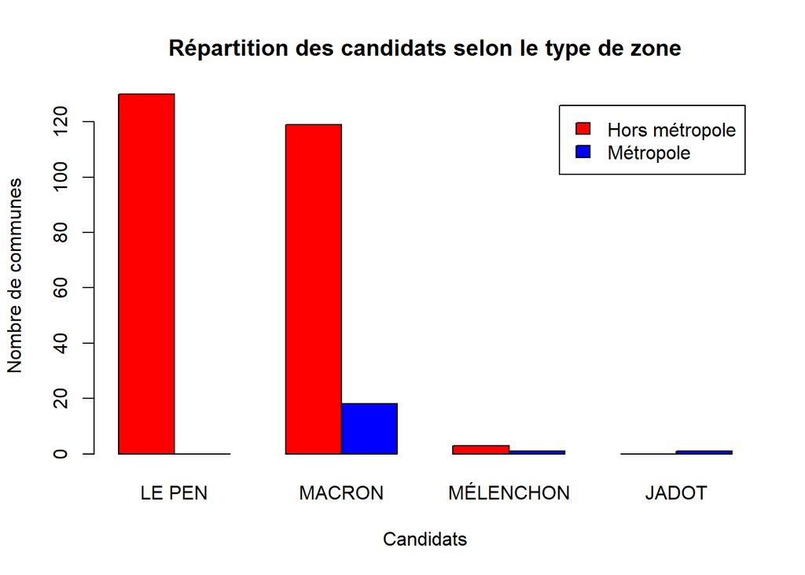

Ces observations confirment les tendances géographiques déjà mises en évidence par la carte interactive et l’analyse des résultats, où l’on a noté des différences notables dans la répartition du soutien aux candidats en fonction de leur localisation géographique. La **signification statistique** de cette répartition, démontrée par le test de Fisher, montre que le **statut géographique** des communes (métropole ou hors métropole) joue un rôle déterminant dans le choix des candidats majoritaires.

### Introduction d’un test de comparaison : Test binomial

Afin d’approfondir notre analyse des résultats électoraux, nous allons procéder à un **test de proportion** pour comparer la proportion de communes où **Emmanuel Macron** est majoritaire avec un **standard hypothétique**. Cet objectif permet d’évaluer si la performance de Macron dans les communes est statistiquement différente de ce que l’on pourrait attendre sous une hypothèse de proportion fixée (ici, 30%).

Les **hypothèses statistiques** sont les suivantes:  
- **H0** : La proportion de communes où Macron est majoritaire est égale au standard de 30% (pas de différence significative).  
- **H1** : La proportion de communes où Macron est majoritaire diffère du standard de 30% (il y a une différence significative).

Dans ce test, nous supposons qu’il existe une hypothèse de travail selon laquelle nous nous attendons à ce que **30% des communes** soient remportées par Macron, et nous allons comparer cette hypothèse avec la proportion réelle observée de communes où il est majoritaire.

### Introduction à la comparaison entre Macron et Le Pen

Dans cette analyse, nous comparons les performances électorales d’**Emmanuel Macron** et de **Marine Le Pen** en termes de **proportions de communes** remportées par chaque candidat. L’objectif est de déterminer s’il existe une différence statistiquement significative entre la proportion de communes où Macron et Le Pen sont majoritaires.

Les **hypothèses statistiques** testées sont les suivantes :

- **H0** : Les proportions de communes remportées par Macron et Le Pen sont égales, ce qui signifie qu’il n’y a pas de différence significative dans les résultats électoraux des deux candidats.
- **H1** : Les proportions de communes remportées par Macron et Le Pen sont différentes, indiquant qu’il existe une différence significative entre les deux candidats en termes de soutien électoral.

Ce test nous permettra de déterminer si les résultats électoraux des deux candidats sont statistiquement distincts ou s’ils reflètent une répartition similaire des communes.

Le test de Fisher montre qu’il n’y a pas de preuve statistique d’une différence significative entre les deux candidats dans cet échantillon, et l’incertitude sur l’odds ratio est élevée en raison de la large plage de l’intervalle de confiance. C’est la raison pour laquelle nous devons prendre en compte la zone géographique de la commune.

[figure not shown]

# Conclusion

L’analyse des élections présidentielles dans l’Indre-et-Loire révèle une interaction complexe entre **dynamiques géographiques et démographiques**, influençant directement les résultats électoraux.

D’un autre côté, les **dynamiques démographiques** apportent une nuance supplémentaire à cette opposition. Les électeurs **plus jeunes et mieux éduqués** des centres urbains montrent une affinité pour des candidats progressistes, tandis que les électeurs **plus âgés et souvent moins diplômés** des zones rurales tendent à soutenir des partis plus traditionnels ou populistes. La corrélation entre l’âge et la participation souligne que les **55-64 ans** sont les plus enclins à voter, tandis que les **15-24 ans** affichent une participation nettement plus faible, particulièrement en métropole.

Ainsi, les **dynamiques géographiques et démographiques** dans l’Indre-et-Loire façonnent un paysage électoral polarisé, où les disparités sociales, économiques et territoriales interagissent pour déterminer les comportements de vote. Ces facteurs jouent un rôle déterminant dans l’interprétation des résultats et dans la compréhension des enjeux locaux qui influencent les choix des électeurs.

[figure not shown]